# SI 618: Data Manipulation and Analysis

## Q5: (Homework Review) Create a pairplot for the wine dataset that plots 'good' and 'bad' wines in different hues. In a couple of sentences, describe interesting relationships shown by the visualization.

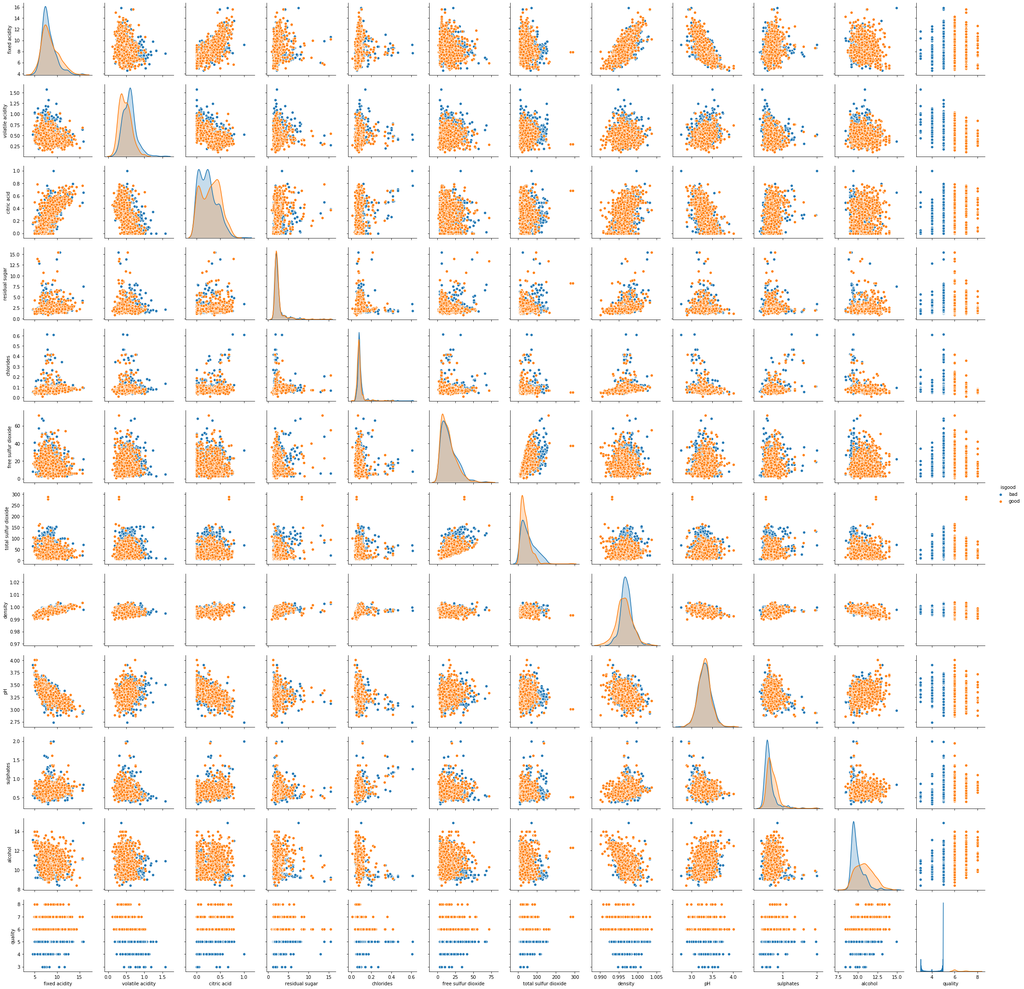

```python
# insert your code here
sns.pairplot(data = wine, hue = "isgood")
```

One of the most interesting relationships shown by the visualization is the relationship between alcohol content and good/bad determination. Good wines tend to have more alcohol content compared to their low alcohol content and "bad" companions.

### Q6: Based on the previous pairplot, for which variables would you expect to see significant differences between good and bad wines?

Insert your answer here. Given the pairplot, I would expect to see significant differences between good and bad wines depending on alcohol content, density, and citric acid. In those plots, the distributions begin to stray from one another the most compared to all of the other variables.

## T-test

A t-test is a simple statistical model that's commonly used to test whether the means of two different distributions are the same. scipy.stats gives us a handy interface for this:

```python
import scipy.stats as stats
```

```python
goodwines = wine.query('isgood == "good"') #Are the means for the two groups different?
badwines = wine.query('isgood == "bad"')
```

```python
stats.ttest_ind(wine[wine.isgood == 'good']['fixed acidity'],wine[wine.isgood == 'bad']['fixed acidity'])

# Get the value of T, which tells you how many standard deviations the means are away from one another
# The p value is likelihood that this happens by chance.
# less than 0.05 is significantly different (the alpha value)
```

```
Ttest_indResult(statistic=3.817471367791021, pvalue=0.00013997664808333373)
```

```python
stats.ttest_ind(wine[wine.isgood == 'good']['fixed acidity'],wine[wine.isgood == 'bad']['fixed acidity'],equal_var=False)

# There is an assumption that the variances of the two classes are the same, add equal_var = false to remove that assumption
```

```
Ttest_indResult(statistic=3.8622483322298358, pvalue=0.0001168399738420885)
```

### Q7: Use t-tests to determine whether there are significant differences between good and bad wines for the variables you listed in the previous question. Are there significant differences?</a>

```python
# insert your code here

print(stats.ttest_ind(wine[wine.isgood == 'good']['alcohol'],wine[wine.isgood == 'bad']['alcohol'],equal_var=False))
print(stats.ttest_ind(wine[wine.isgood == 'good']['citric acid'],wine[wine.isgood == 'bad']['citric acid'],equal_var=False))
print(stats.ttest_ind(wine[wine.isgood == 'good']['density'],wine[wine.isgood == 'bad']['density'],equal_var=False))
```

```
Ttest_indResult(statistic=19.78218499094004, pvalue=1.139484979294959e-77)
Ttest_indResult(statistic=6.479899656822674, pvalue=1.2203594771190347e-10)
Ttest_indResult(statistic=-6.554124593132584, pvalue=7.561697265393993e-11)
```

Even with a conservative estimate (setting equal variance equal to false), all three variables have statistically significant differences when using a t-test. Each of their p values is below the alpha of 0.05.

### Q8: Using the JointGrid approach we used above look at the relationship between sulphates and chlorides. What patterns do you see?

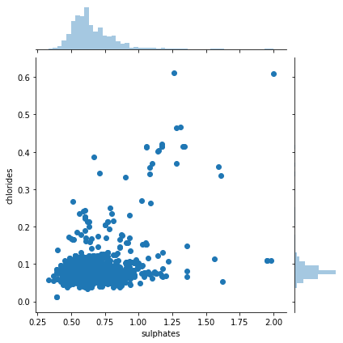

```python
# insert your code here
sns.jointplot(data = wine, x = "sulphates", y = "chlorides")
```

It appears that sulphates and chlorides tend to cluster below 0.3 chlorides and 1.25 sulphides.

## Ordinary Least Squares (OLS) Regression

We can get a lot more detail about the regression model by using statsmodels

```python
import statsmodels.api as sm
import statsmodels.formula.api as smf
```

statsmodels.formula.api allows you to use R-Style formulas: y ~ x1 + x2 + x3 + ...

1. y represents the outcome/dependent variable
2. x1, x2, x3, etc represent explanatory/independent variables

```python
model1 = smf.ols('chlorides ~ sulphates', data=wine).fit() # chlorides (y) varies on sulphates (x)
model1.summary()

# R-squared: 13.8% of the variance is explained by the relationship between sulphates and chlorides
# F-statistic (255.3) what's the likelihood of this relationship happening by chance? (199e - 53)

#  y = b0 + b1 (chlorides = 0.0196 + 0.1031x)
```

OLS Regression Results

| Dep. Variable: | chlorides | R-squared: | 0.138 |
| --- | --- | --- | --- |
| Model: | OLS | Adj. R-squared: | 0.137 |
| Method: | Least Squares | F-statistic: | 255.3 |
| Date: | Mon, 17 Feb 2020 | Prob (F-statistic): | 1.99e-53 |
| Time: | 10:51:24 | Log-Likelihood: | 2737.1 |
| No. Observations: | 1599 | AIC: | -5470. |
| Df Residuals: | 1597 | BIC: | -5459. |
| Df Model: | 1 |  |  |
| Covariance Type: | nonrobust |  |  |

|  | coef | std err | t | P>\|t\| | [0.025 | 0.975] |
| --- | --- | --- | --- | --- | --- | --- |
| Intercept | 0.0196 | 0.004 | 4.475 | 0.000 | 0.011 | 0.028 |
| sulphates | 0.1031 | 0.006 | 15.978 | 0.000 | 0.090 | 0.116 |

| Omnibus: | 1419.606 | Durbin-Watson: | 1.779 |
| --- | --- | --- | --- |
| Prob(Omnibus): | 0.000 | Jarque-Bera (JB): | 51655.663 |
| Skew: | 4.079 | Prob(JB): | 0.00 |
| Kurtosis: | 29.622 | Cond. No. | 8.51 |

Warnings:  
[1] Standard Errors assume that the covariance matrix of the errors is correctly specified.

```python
wine.describe()
```

[output not shown]

### Q9: What is the expected value of chlorides for a wine with a sulphates value of 0.8?</a>

Insert your answer here. Show how you calculated the value.

y = b0 + b1

chlorides = 0.0196 + 0.1031x

chlorides = 0.0196 + 0.1031 * 0.8

Expected value of chlorides = 0.10208

### Interesting things happen when we use OLS to do an ANOVA (look closely at the model):

```python
model2 = smf.ols('chlorides ~ C(isgood)', data=wine).fit() # Checks the categorical representation of isgood
model2.summary() #Are the mean values of the good/isgood groups different?

# C(isgood)[t.good] is the offset if the wine is good
```

OLS Regression Results

| Dep. Variable: | chlorides | R-squared: | 0.012 |
| --- | --- | --- | --- |
| Model: | OLS | Adj. R-squared: | 0.011 |
| Method: | Least Squares | F-statistic: | 19.38 |
| Date: | Mon, 17 Feb 2020 | Prob (F-statistic): | 1.14e-05 |
| Time: | 11:04:19 | Log-Likelihood: | 2628.2 |
| No. Observations: | 1599 | AIC: | -5252. |
| Df Residuals: | 1597 | BIC: | -5242. |
| Df Model: | 1 |  |  |
| Covariance Type: | nonrobust |  |  |

|  | coef | std err | t | P>\|t\| | [0.025 | 0.975] |
| --- | --- | --- | --- | --- | --- | --- |
| Intercept | 0.0930 | 0.002 | 54.200 | 0.000 | 0.090 | 0.096 |
| C(isgood)[T.good] | -0.0103 | 0.002 | -4.402 | 0.000 | -0.015 | -0.006 |

| Omnibus: | 1776.944 | Durbin-Watson: | 1.871 |
| --- | --- | --- | --- |
| Prob(Omnibus): | 0.000 | Jarque-Bera (JB): | 121109.713 |
| Skew: | 5.649 | Prob(JB): | 0.00 |
| Kurtosis: | 44.111 | Cond. No. | 2.71 |

Warnings:  
[1] Standard Errors assume that the covariance matrix of the errors is correctly specified.

```python
aov_table = sm.stats.anova_lm(model2, typ=2)
print(aov_table)
```

[output not shown]